# Simple Linear Regression

### Problem Statement:-

- Build a prediction model for Salary_hike

### Data Understanding

```r
sal <- read.csv("~/desktop/Digi 360/Module 6/DataSets-4/Salary_Data.csv")
head(sal)
```

```
##   YearsExperience Salary
## 1             1.1  39343
## 2             1.3  46205
## 3             1.5  37731
## 4             2.0  43525
## 5             2.2  39891
## 6             2.9  56642
```

```r
#renaming the columns
colnames(sal) <- c("exp","salary")
```

```r
# checking the summary
summary(sal)
```

```
##       exp             salary
##  Min.   : 1.100   Min.   : 37731
##  1st Qu.: 3.200   1st Qu.: 56721
##  Median : 4.700   Median : 65237
##  Mean   : 5.313   Mean   : 76003
##  3rd Qu.: 7.700   3rd Qu.:100545
##  Max.   :10.500   Max.   :122391
```

Here, the mean is greater than the median for experience so the distribution is right skewed.

Similarly, the mean is greater than the median for salary hike so the distribution is right skewed.

### Visualization

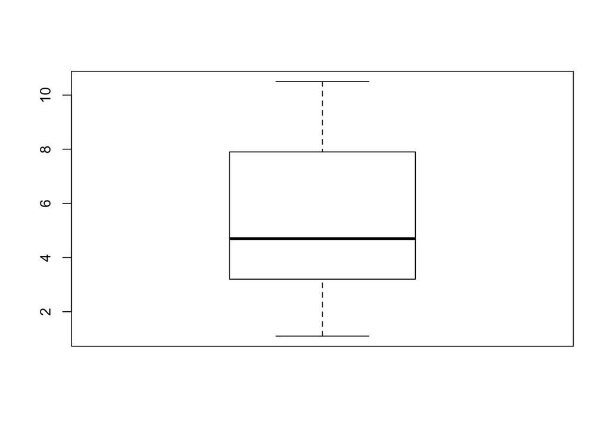

```r
x <- boxplot(sal$exp)
```

```r
x$out
```

```
## numeric(0)
```

So, there are no outliers.

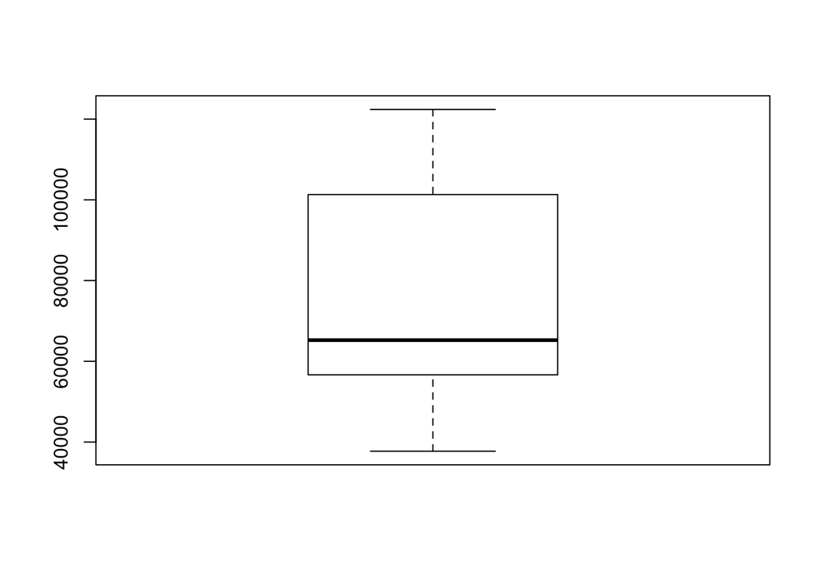

```r
y <- boxplot(sal$salary)
```

```r
y$out
```

```
## numeric(0)
```

So, there are no outliers.

Let’s draw scatter diagram to see the relationship between salary hike and Experience.

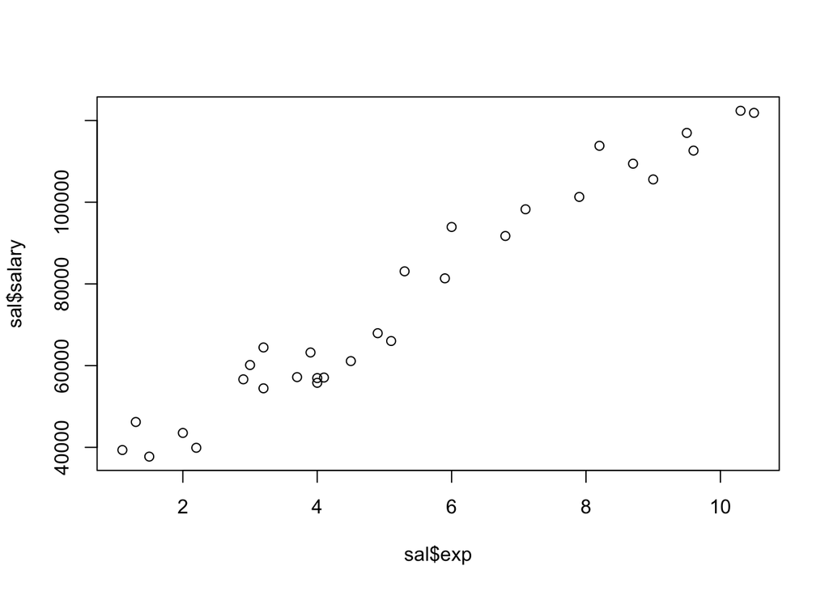

```r
plot(sal$exp, sal$salary) # Scatter plot
```

### Correlation

```r
cor(sal$exp, sal$salary)
```

```
## [1] 0.9782416
```

Here the correlation coefficient value is 0.98 which is greater than 0.85. So, the relationship between salary hike and years of experience is strong.

### Building the model

```r
model <- lm(sal$salary ~ sal$exp)
summary(model)
```

```
##
## Call:
## lm(formula = sal$salary ~ sal$exp)
##
## Residuals:
##     Min      1Q  Median      3Q     Max
## -7958.0 -4088.5  -459.9  3372.6 11448.0
##
## Coefficients:
##             Estimate Std. Error t value Pr(>|t|)
## (Intercept)  25792.2     2273.1   11.35 5.51e-12 ***
## sal$exp       9450.0      378.8   24.95  < 2e-16 ***
## ---
## Signif. codes:  0 '***' 0.001 '**' 0.01 '*' 0.05 '.' 0.1 ' ' 1
##
## Residual standard error: 5788 on 28 degrees of freedom
## Multiple R-squared:  0.957,  Adjusted R-squared:  0.9554
## F-statistic: 622.5 on 1 and 28 DF,  p-value: < 2.2e-16
```

So, the linear equation is y^ = 25792.2 + 9450x. Here y^ = salary hike and x = years of experience.

### Model Evolution

Here p value is less than 0.05 so we reject the null hypothesis. That means there is significant correlation between salary hike and years of experience.

Here we also can see R-squared value is 0.957 which is greater than 0.85. Hence our model is good and we don’t need further transformations.

Since we are ready with equation, let’s predict the values with 95% CI level.

```r
pred <- predict(model, sal)
model$residuals
```

```
##          1          2          3          4          5          6          7
##  3155.8412  8127.8488 -2236.1437 -1167.1248 -6691.1173  3444.9091  6007.9128
##          8          9         10         11         12         13         14
## -1587.0796  8412.9204 -3568.0608   570.9467 -7798.0495 -6635.0495 -7456.0457
##         15         16         17         18         19         20         21
## -7206.0306 -4159.0156 -7958.0080  7210.9995  -183.9779 11448.0259  1686.0560
##         22         23         24         25         26         27         28
##  5386.0673   855.0975 10530.1088  1424.1276 -5259.8611  1402.1577 -3876.8385
##         29         30
##  -735.8121 -3144.8046
```

```r
confint(model, level =0.95)
```

```
##                 2.5 %   97.5 %
## (Intercept) 21136.061 30448.34
## sal$exp      8674.119 10225.81
```

```r
predict(model, interval = "confidence")
```

```
##          fit       lwr       upr
## 1   36187.16  32266.47  40107.84
## 2   38077.15  34284.87  41869.43
## 3   39967.14  36301.20  43633.09
## 4   44692.12  41331.43  48052.82
## 5   46582.12  43338.57  49825.66
## 6   53197.09  50334.94  56059.24
## 7   54142.09  51330.08  56954.10
## 8   56032.08  53316.48  58747.68
## 9   56032.08  53316.48  58747.68
## 10  60757.06  58256.48  63257.64
## 11  62647.05  60220.43  65073.68
## 12  63592.05  61199.48  65984.62
## 13  63592.05  61199.48  65984.62
## 14  64537.05  62176.47  66897.62
```

[output cut: 16 more lines]

### Accuracy

Now let’s find out the accuracy.

```r
#Finding RMSE
rmse <- sqrt(mean(model$residuals^2))
rmse
```

```
## [1] 5592.044
```

So, we can conclude that our predicted values are 5592 points deviated from actual values.

Now let’s visualize the predicted values using a ggplot to add a regression line to it.

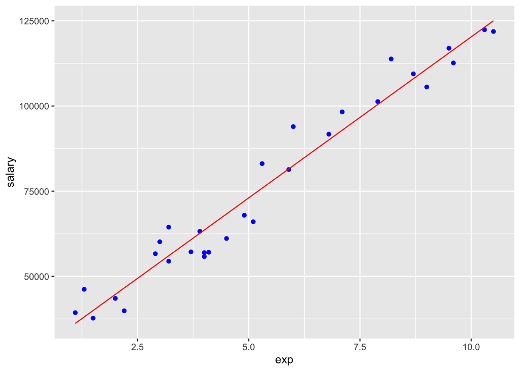

```r
library(ggplot2)
ggplot(data=sal,aes (x = exp, y = salary)) +
 geom_point(color='blue') +
 geom_line(color = 'red', data=sal,aes (x = exp, y = pred))
```

### Conclusion:-

- The model R^2 is 0.96. So, our model is good.